# Lab: K-Means

Author

Maimoona Abdaal

**Getting Started**

1. Download the `.qmd` file from Moodle and any needed `.xlsx` or `.csv` data files. Save these in the *same folder/directory*.
2. Open the Quarto file in RStudio: `File > Open File... >`. If you’re working on the MHC RStudio server, you need to upload the files first: go to the `Files` panel, then click `Upload`. Upload the `.qmd` file and any data files. You will need to upload each file one at a time.
3. Update the author and date in the YAML header of this file.
4. Click the `Render` button. If successful, you should have a new window pop up with a nice looking HTML document.
5. For this lab, you **may need** to still the package `glmnet`.

**Ask for help** if you encounter issues on any of the steps above. Once you’ve successfully made it through these steps, you can continue.

# Load Packages

You likely will need to install some these packages before you can run the code chunk below successfully.

```r
library(tidyverse)
library(palmerpenguins)
library(factoextra)
library(amap)
```

# Load Penguin Data

```r
data(penguins)
```

# Data Cleaning

```r
# Remove missing values
# YOUR CODE HERE
penguins <- penguins %>%
            filter(!is.na(bill_length_mm) & !is.na(bill_depth_mm) & !is.na(species))

# Make data table (named penguins_reduced) that only has
# bill_length_mm and bill_depth_mm columns
penguins_reduced <- penguins %>% select(bill_length_mm, bill_depth_mm)
```

# Initial Visualization

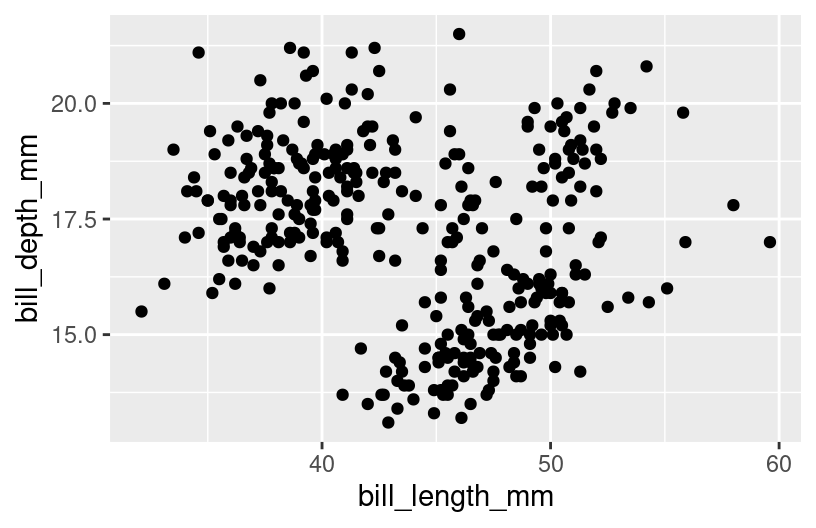

```r
ggplot(penguins, aes(x = bill_length_mm, y = bill_depth_mm)) +
  geom_point()
```

We’ll cluster these penguins based on their bill lengths and depths:

# Implement $K$-Means

Complete the code below to run the K-means algorithm using K = 3.

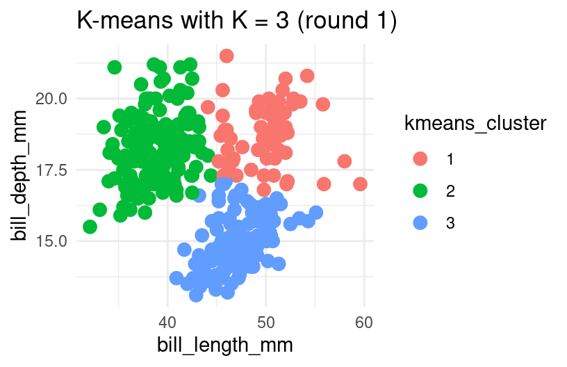

```r
set.seed(244)
# Run the K-means algorithm
kmeans_3_round_1 <- kmeans(scale(penguins_reduced), centers = 3)

# Plot the cluster assignments
penguins_reduced %>%
  mutate(kmeans_cluster = as.factor(kmeans_3_round_1$cluster)) %>%
  ggplot(aes(x = bill_length_mm, y = bill_depth_mm, color = kmeans_cluster)) +
  geom_point(size = 3) +
  theme(legend.position = "none") +
  labs(title = "K-means with K = 3 (round 1)") +
  theme_minimal()
```

- Why do we have to set the seed for K-means? In practice, why should we try out a variety of seeds?

**Answer.** For reproducibility. Every time we run the function `kmeans`, it initializes the centers of the clusters to be in random locations. It’s possible that some random locations give better clustering results than others; since k-means is a greedy algorithm, it’s possible for it to have a different result each time, and it’s possible for it to get “stuck” at a local solution.

# K-Means Clusters Versus Known Species Groupings

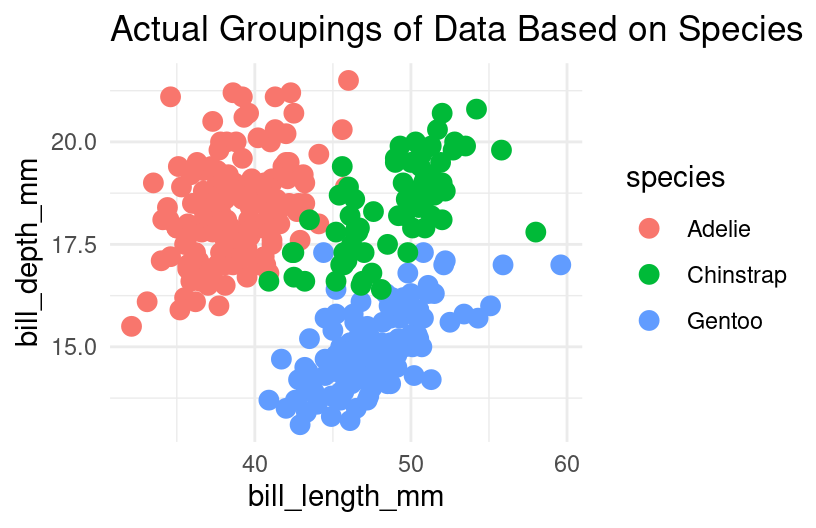

```r
  ggplot(data = penguins, aes(x = bill_length_mm, y = bill_depth_mm, color = species)) +
  geom_point(size = 3) +
  theme(legend.position = "none") +
  labs(title = "Actual Groupings of Data Based on Species") +
  theme_minimal()
```

- Visually, how well do you think $K$-means captured the underlying species structure of the data?

**Answer.** I think it did pretty good! It found roughly the data points corresponding to each of the species groups, so it is identifying that as a way to structure the data.

# Tuning $K$

- To implement K-means clustering we must choose an appropriate K! Use the following example to see the two different extreme situations. Typically, the ideal $K$ is somewhere between the two extremes.
- **Minimum:** $K = 2$ groups/clusters
- **Maximum:** $K = n$ groups/clusters (one observation per cluster)

What happens in the $K$-means algorithm if $K = n$?

Let’s consider anywhere from $K = 2$ to $K = 20$ clusters.

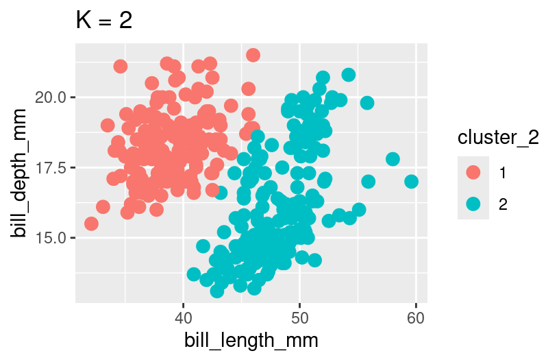

```r
set.seed(244)

k_2  <- kmeans(scale(penguins_reduced), centers = 2)
k_20 <- kmeans(scale(penguins_reduced), centers = 20)

penguins_reduced %>%
  mutate(cluster_2 = as.factor(k_2$cluster)) %>%
  ggplot(aes(x = bill_length_mm, y = bill_depth_mm, color = cluster_2)) +
    geom_point(size = 3) +
    labs(title = "K = 2")
```

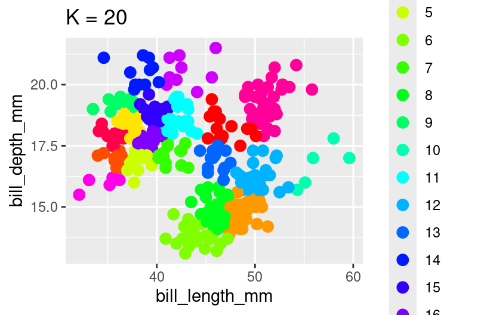

```r
penguins_reduced %>%
  mutate(cluster_20 = as.factor(k_20$cluster)) %>%
  ggplot(aes(x = bill_length_mm, y = bill_depth_mm, color = cluster_20)) +
    geom_point(size = 3) +
    labs(title = "K = 20") +
    scale_color_manual(values = rainbow(20))
```

What are your general impressions?

# Finding Ideal K Value: Silhoutte

- The *average silhouette approach* measures the quality of a clustering. That is, it determines how well each object lies within its cluster.
  - To do so, it maximizes the distance between clusters and minimizes distance within clusters.
- A high average silhouette indicates a good clustering.
- Given a range of possible K values, the optimal number of clusters (K) is the one that maximizes the average silhouette.

We can use a built-in silhouette method in the `fviz_nbclust` function to compute the average silhouette for various K values.

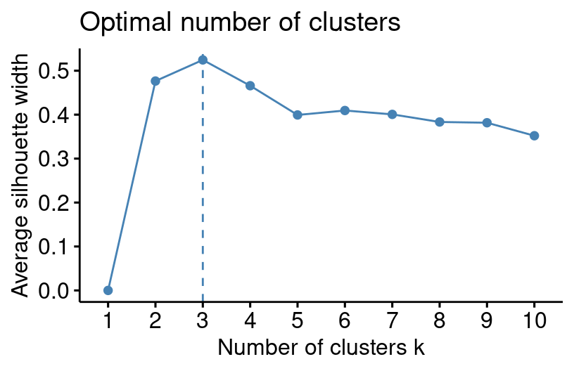

```r
fviz_nbclust(scale(penguins_reduced), kmeans, method='silhouette')
```

Based on the *average silhouette approach*, what is the optimal $K$ value?

**Answer.** The optimal value for $K$ appears to be $K$ = 3

# Experimenting with Distance Metrics

We can use the `Kmeans` method (notice the “K” is capitalized in this function name) from the `amap` library to specify how we are measuring distance in the K-means algorithm.

[figure not shown]

```r
set.seed(244)
k_2_manattan = Kmeans(scale(penguins_reduced), centers = 3,
                      method = "manhattan")
k_2_euclid = Kmeans(scale(penguins_reduced), centers = 3,
                    method = "euclidean")
k_2_maxnorm = Kmeans(scale(penguins_reduced), centers = 3,
                     method = "maximum")



fviz_cluster(k_2_euclid, data = scale(penguins_reduced),
             main = sprintf("K = %d Clusters w/ Manhattan Distance", 3))
```

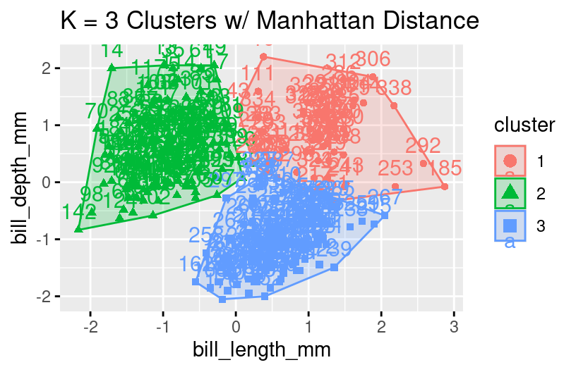

```r
fviz_cluster(k_2_manattan, data = scale(penguins_reduced),
             main = sprintf("K = %d Clusters w/ Manhattan Distance", 3))
```

[figure not shown]

```r
fviz_cluster(k_2_maxnorm, data = scale(penguins_reduced),
             main = sprintf("K = %d Clusters w/ Manhattan Distance", 3))
```

Try changing $K$ to equal 3$ in the code chunk above. How do the clusterings using the 3 distance metrics compare? What do you generally observe?

Modify the code in the chunk above so that we can easily change the value of K (rather than making sure to change K manually in every line). In general coding practices, is called *extracting out a constant.*